# Lecture #3: Transforming and Combining Functions

MATH 145 – Calculus I

Torin Quinlivan

tquinlivan@knox.edu

Knox College

September 29, 2025

## More Complex Functions

Last time, we discussed some of the basic types of functions.

We also discussed compositions, one of the ways to combine simpler functions to make more complicated ones.

There are more ways to combine or change functions.

## Piecewise Functions

A **piecewise function** is a function that has different formulas on different intervals.

**Example:** The absolute value function $f(x) = \vert x \vert$ returns $x$ if $x$ is positive, and $-x$ if $x$ is negative. We can write this as:
$$f(x) = \begin{cases}
-x & \textrm{if } x < 0 \\
x & \textrm{if } x \ge 0 \\
\end{cases}$$

## Piecewise Functions

**Example:**
$$f(x) = \begin{cases}
x + 3 & \textrm{if } x < 2 \\
x^2 & \textrm{if } 2 \le x \le 4 \\
2x - 4 & \textrm{if } x > 4
\end{cases}$$

Evaluate $f(1)$, $f(2)$, $f(3)$, $f(4)$ and $f(5)$.

Graph $f(x)$.

## Piecewise Functions

**Example:** Determine the formula for the piecewise function shown below:

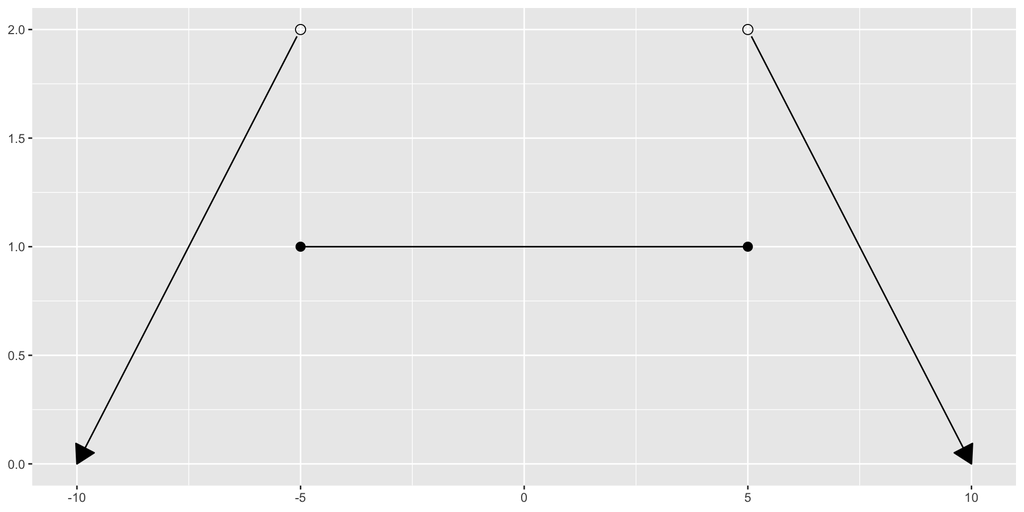

## Piecewise Functions

**Example:** Determine the formula for the piecewise function shown below:

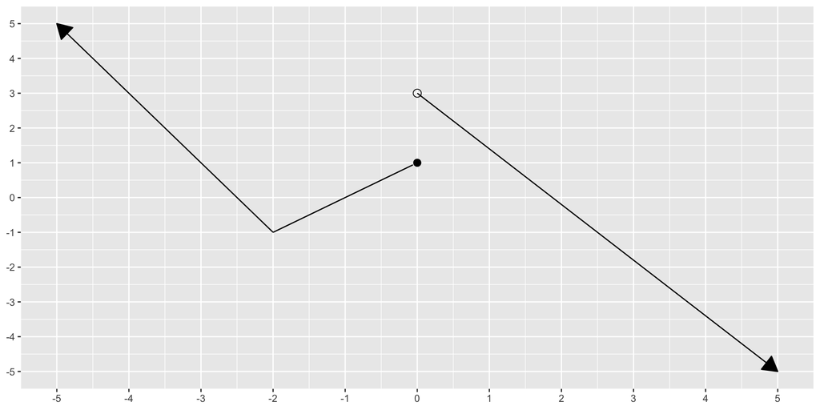